# {{ page.title }}

## 3. Estimating Heritability: LD Score Regression

To estimate the SNP-heritability of a trait using GWAS summary statistics, we can perform LD score regression, which involves regressing SNP test-statistics against their LD scores (the sum of LD with all other SNPs), and rescaling the slope by the number of common SNPs (MAF>0.05), and the sample size of the GWAS. The SNP test-statistics we are interested in are the chi-squared (X<sup>2</sup>) statistics, which can be derived from the beta effect estimates.

From the equation below, we can see that there are 3 contributors to test-statistic inflation for each SNP: inflation from polygenicity, inflation from confounding bias and inflation from estimation errors.

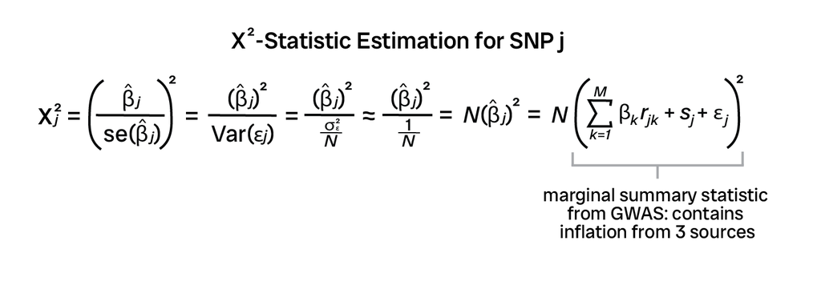

To distinguish polygenicity inflation from from confounding bias and estimation error inflation, LD score regression can be performed by fitting a linear regression between the test-statistics and LD scores for each SNP. The regression line for expected chi-squared values is derived by:

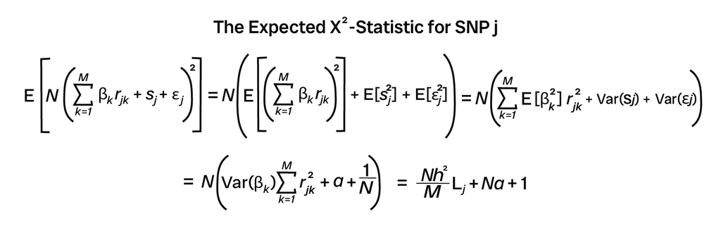

From this equation we get separate terms relating to heritability and confounding, as shown below:

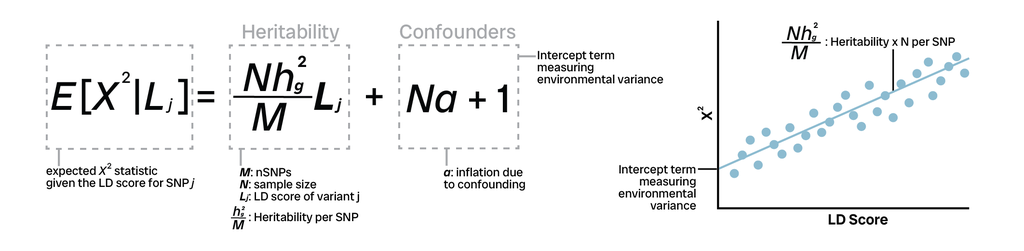

So by performing a linear regression on the test-statistics and LD scores for each SNP, we can estimate heritability (h2) by rescaling the regression slope by N (the sample size) and M (the number of common SNPs used in LD score estimation), and we can also estimate the environmental variance from the intercept term.

## 4. Estimating Heritability: LD Score Regression in R

To demonstrate how heritability can be estimated using LD score regression, in the code below I have simulated two seperate datasets: one where LD score and beta are highly correlated (reflecting a trait with high SNP heritability), and one where LD score has no relationship with beta (reflecting a trait with low SNP heritability). It is important to note that these simulated datasets are not necessarily reflective of real GWAS datasets: the distribution of beta and LD scores would not be uniform.

```r
# Create an empty dataframe
Sim1 <- data.frame(matrix(vector(), 500000, 3, dimnames=list(c(), c("SNP", "L2", 'beta'))), stringsAsFactors=F)

# Add SNP names and LD scores
Sim1$SNP <- sprintf("rs%s",seq(1:500000))
Sim1$L2 <- seq(0,40, length.out=500000)

# Simulate values correlated with LD score
Sim1$beta <- seq(0,0.3, length.out=500000)

# Add random inflation of beta across all SNPs
Sim1$beta <- Sim1$beta+0.05

# Set standard error
Sim1$standard_error <- 0.1

# Set number of SNPs used for LD score calculation
M <- 40000

# Set number of people in simulated GWAS
N <- 30000
```

We will look at simulated dataset 1 first. First we need to get the z-score and chi-squared statistic for each SNP:

```r
# Get z-score (beta/beta_se)
Sim1$Z <- Sim1$beta/Sim1$standard_error

# Get chi2-statistic (Z-score**2)
Sim1$Z2 <- Sim1$Z**2
ChiSq <- Sim1$Z2

# Get LD scores
LD <- Sim1$L2
```

With the information we have so far, we can make a crude estimate of the h2 value for this simulated dataset using the following formula:

```r
h2Est <- (M*(mean(ChiSq)-1))/(mean(N*LD))
h2Est
```

```
## [1] 0.2500002
```

Step 1: Intercept

To perform LD score regression we need to calculate two components: the intercept and the gradient of the slope. In step 1 we will calculate the intercept using only data with a chi-squared score below 30. First we can create all the variables we need:

```r
# Subset data to get SNPs with a Z2 below 30
Sim1_30 <- subset(Sim1, Z2<30)

# Get LD scores
LDscores <- round(as.matrix(Sim1_30$L2), 4)

# Add intercept (start at 1)
LDscoresInt <- cbind(LDscores, Int=(rep(1,nrow(Sim1_30))))

# Get chi-squared statistics
ChiSqStats <- round(as.matrix(Sim1_30$Z2), 4)
```

LD score regression involves iteratively weighting each SNP, as the LD score-chi-square relationship fails some assumptions of the linear model:

- Because chi-squared statistics are not independent (due to LD), over-counting is corrected by down-weighting each SNP in proportion to its LD score
- The variance between the chi-squared statistics for each SNP is not homoscedastic: chi-squared statistics of SNPs with a high LD score have higher variance. Because of this, a heteroscedasticity weight is also implemented.
- Regression is weighted by the product of the over-counting weight and the heteroscedasticity weight.

Using these two weights, LD score regression involves iteratively re-weighting the slope, using a precision of 4 iterations. The code below defines the weighting functions we need:

```r
# Function to get weighting
GetWeights <- function(h2, LD, wLD, N, M, Int){

  # Make sure h2 is between 0-1
  h <- max(h2,0.0)
  h <- min(h,1.0)

  # Replaces values above 1 with 1
  LD <- pmax(LD, 1.0)
  wLD <- pmax(wLD, 1.0)

  # Get gradient of line by multiplying by N/M
  c <- h*N/M

  # Generate heteroscedasticity weights
  hetW <- 1/(2*(Int+c*LD)**2)

  # Generate overcounting weights
  ocW <- 1/wLD

  # Get weightings
  w <- hetW*ocW
  return(w)
}

# Function to add weights
Weight <- function(w, x){
  w1 <- sqrt(w)
  wNorm <- w1/sum(w1)
  xW <- x*wNorm
  return(xW)
}

# Function to estimate h2 from slope
H2Estimate <- function(coefficient, M, N){M*coefficient/N}
```

Using these functions, we can iteratively re-weight our regression slope 4 times, using the crude estimate and an intercept of 1 as a starting point:

```r
h2W <- h2Est
regInt <- 1
precision <- 4

for(i in 1:precision){

  # Get initial weighting
  initialW <- as.vector(GetWeights(h2W, LDscores, LDscores, N, M, regInt))

  # Weight LD intercept
  LDscoresIntW <- Weight(initialW, LDscoresInt)

  # Weight ChiSq statistics
  ChiSqStatsW <- Weight(initialW, ChiSqStats)

  # Get coefficient of re-weighted LDscores and ChiSq statistics
  coefW <- summary(lm(ChiSqStatsW~0+LDscoresIntW))$coef

  # Set new regression slope
  regCoef <- coefW[1,1]

  # Set new regression intercept
  regInt <- coefW[2,1]

  # Get new h2 and intercept values
  h2W <- H2Estimate(regCoef, M, N)
  message(paste0('Reweighted Intercept: ', regInt))
}
```

```
## Reweighted Intercept: 0.0723155079498401
```

```
## Reweighted Intercept: 0.176213720052027
```

```
## Reweighted Intercept: 0.154587545181594
```

```
## Reweighted Intercept: 0.159845534320509
```

To get an estimate for the standard error of the intercept, we have to employ a block jackknife. This is an iterative resampling method, where jackknife samples are taken by leaving out blocks of SNPs one by one. Each time a block is removed, the intercept is re-estimated, and pseudovalues are computed - these are the difference between the estimate from all of the data and the jackknife estimate. The standard error can be estimated from the standard deviation of the psuedovalues.

```r
JackknifeIntercept <- function(Sim_30, LDscoresIntW, ChiSqStatsW){

  # First we get the number of SNPs with Z2<30
  N1 <- nrow(Sim1_30)

  # Split rows into 200 blocks
  blockValues <- seq(0, N1, length.out=201)
  nBlocks <- 200

  # For each block, generate a 2x2 matrix
  xBlockValues <- list()
  for (i in 1:nBlocks){
    xBlockValues[[i]]<- matrix(0,2,2)
  }

  # Make matrix of 2 x nBlocks
  yBlockValues <- matrix(0, nBlocks, 2)

  # Get values for each block
  for(i in 1:nBlocks){
    xBlockValues[[i]]<-t(LDscoresIntW[blockValues[i]:(blockValues[i+1]-1),])%*%LDscoresIntW[blockValues[i]:(blockValues[i+1]-1),]
    yBlockValues[i,]<-t((LDscoresIntW[blockValues[i]:(blockValues[i+1]-1),]))%*%(ChiSqStatsW[blockValues[i]:(blockValues[i+1]-1 ),])
  }

  # Solve x,y to convert block values to estimate
  y <- colSums(yBlockValues)
  x <- xBlockValues[[1]]
  for(i in 2:length(xBlockValues)){
    x <- x+xBlockValues[[i]]
  }

  est <- t(as.matrix(solve(x,y)))

  # Delete each block value
  delValues <- matrix(0, nBlocks, 2)
  yTot <- colSums(yBlockValues)
  xTot <- xBlockValues[[1]]
  for(i in 2:length(xBlockValues)){
    xTot <- xTot+xBlockValues[[i]]
  }
  for(i in 1:nBlocks){
    yDel <- yTot - yBlockValues[i,]
    xDel <- xTot - xBlockValues[[i]]
    delValues[i,] <- solve(xDel, yDel)
  }

  delValuesStep1 <- delValues

  # Slope estimates
  pseudoValues1 <- nBlocks*est[1,1]-(nBlocks-1)*delValues[,1]

  # Intercept estimates
  pseudoValues2 <- nBlocks*est[1,2]-(nBlocks-1)*delValues[,2]

  # Combine
  pseudoValuesStep1 <- cbind(pseudoValues1, pseudoValues2)

  # Jackknife estimates
  jknifeCov <- cov(pseudoValuesStep1)/nBlocks
  jknifeVar <- diag(jknifeCov)
  jknifeSE <- sqrt(jknifeVar)
  jknifeEst <- t(as.matrix(colMeans(pseudoValuesStep1)))

  # Get estimates from step 1
  step1Int <- jknifeEst[1,2]
  step1IntSE <- jknifeSE[2]
  message(paste0('Step 1 Intercept: ', step1Int))
  message(paste0('Step 1 Intercept SE: ', step1IntSE))

  return(c(step1Int, step1IntSE))
}

Sim1JKInt <- JackknifeIntercept(Sim1_30, LDscoresIntW, ChiSqStatsW)
```

```
## Step 1 Intercept: 0.165309803162759
```

```
## Step 1 Intercept SE: 0.0219321086354315
```

```r
step1Int <- Sim1JKInt[1]
step1IntSE <- Sim1JKInt[2]
```

Step 2: Slope

Now that we have an estimate for the intercept, we can use all SNPs (including those with Z2 above 30) and a constrained intercept to estimate the slope gradient (so we can find h2).

```r
# LD scores as a matrix
LD <- Sim1$L2
LDMat <- round(as.matrix(LD),4)

# ChiSq as a matrix
ChiSqMat <- round(as.matrix(ChiSq),4)

# Reduce intercept from y
ChiSqRed<- ChiSqMat-step1Int

# Iterated weights
h2W <- h2Est
regInt <- 1

# Initial weights are crude h2 estimate and intercept 1 - from second round the intercept is the step 1 intercept
for(i in 1:precision){
  initialW <- as.vector(GetWeights(h2W, LDMat, LDMat, N, M, regInt))

  # Weight LD scores
  LDscoresIntW <- Weight(initialW, LDMat)

  # Weight ChiSq statistics
  ChiSqStatsW <- Weight(initialW, ChiSqRed)

  # Get coefficient of re-weighted LDscores and ChiSq statistics
  Coef2 <- summary(lm(ChiSqStatsW~0+LDscoresIntW))$coef
  regCoef2 <- Coef2[1,1]

  # Set regression intercept as value calculated from step 1
  regInt <- step1Int

  # Get new h2 value
  h2W <- H2Estimate(regCoef2, M, N)
  message(paste0('Reweighted h2: ', h2W))
}
```

```
## Reweighted h2: 0.244412424553641
```

```
## Reweighted h2: 0.220660209343455
```

```
## Reweighted h2: 0.221389197937769
```

```
## Reweighted h2: 0.221364588090334
```

We also need to estimate the standard error of the slope - we can also do this using the jackknife method.

```r
JackknifeSlope <- function(LDMat, LDscoresIntW, ChiSqStatsW){

  # Get number of SNPs, and split into 200 blocks
  N2 <- nrow(LDMat)
  blockValues <- (seq(0, N2, length.out = 201))
  nBlocks = 200
  xBlockValues <- list()
  for (i in 1:nBlocks){xBlockValues[[i]] <- matrix(0,1,1)}
  yBlockValues <- matrix(0, nBlocks, 1)
  for (i in 1:nBlocks){
    xBlockValues[[i]]<-t(LDscoresIntW[blockValues[i]:(blockValues[i+1]-1),])%*%LDscoresIntW[blockValues[i]:(blockValues[i+1]-1),]
    yBlockValues[i,]<-t(t((LDscoresIntW[blockValues[i]:(blockValues[i+1]-1),]))%*%(ChiSqStatsW[blockValues[i]:(blockValues[i+1]-1),]))
  }

  # block values to est
  y <- colSums(yBlockValues)
  x <- xBlockValues[[1]]
  for (i in 2: length(xBlockValues)){x <- x+xBlockValues[[i]]}
  est2 <- t(as.matrix(solve(x,y)))

  # block values to delete values
  delValues <- matrix(0, nBlocks, 1)
  yTot <- colSums(yBlockValues)
  xTot <- xBlockValues[[1]]

  for (i in 2: length(xBlockValues)){xTot <- xTot+xBlockValues[[i]]}
  for (i in 1:nBlocks){
    yDel <- yTot-yBlockValues[i,]
    xDel <- xTot-xBlockValues[[i]]
    delValues[i,] <- solve(xDel, yDel)
  }

  # delete values to pseudovalues
  delValuesStep2 <- delValues
  pseudoValues1 <- nBlocks*est2[1,1] - (nBlocks-1)*delValues[,1]
  pseudoValuesStep2 <- as.matrix(pseudoValues1)

  ## Jackknife estimates
  jknifeCov2 <- cov(pseudoValuesStep2)/nBlocks
  jknifeVar2 <- diag(jknifeCov2)
  jknifeSE2 <- sqrt(jknifeVar2)
  jknifeEst2 <- t(as.matrix(colMeans(pseudoValuesStep2)))

  return(c(jknifeSE2, jknifeEst2))

}

Sim1JKSlope <- JackknifeSlope(LDMat, LDscoresIntW, ChiSqStatsW)
jknifeSE2 <- Sim1JKSlope[1]
jknifeEst2 <- Sim1JKSlope[2]
```

Now that we have estimates for the slope and intercept, and we have used a block jackknife method to estimate their respective SEs, we can identify our final estimates:

```r
# Intercept & SE from Step 1
int <- step1Int
intSE <- step1IntSE

# h2 Estimate & SE from Step 2
h2Est <- H2Estimate(jknifeEst2, M, N)
h2EstSE <- H2Estimate(jknifeSE2, M, N)

message(paste0('Intercept: ', round(int, 3), ' (', round(intSE, 3), ')'))
```

```
## Intercept: 0.165 (0.022)
```

```r
message(paste0('h2: ', round(h2Est, 3), ' (', round(h2EstSE, 3), ')'))
```

```
## h2: 0.221 (0.005)
```

We can also use these values to plot an LD score regression plot:

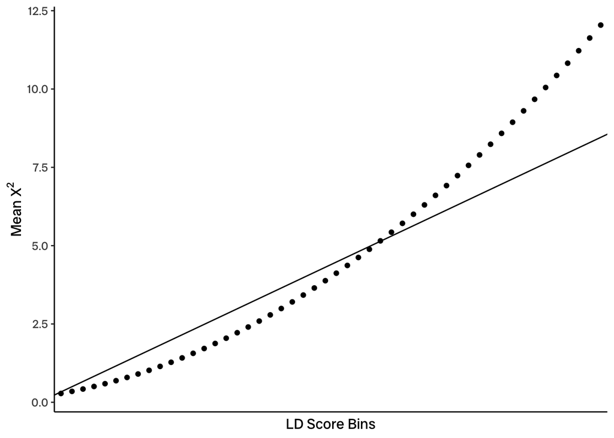

```r
# Group into bins and get summary statistics
SimBins <- Sim1 %>%
  mutate(`LD Score Bins` = cut(L2, breaks=50)) %>%
  group_by(`LD Score Bins`) %>%
  summarise(meanchi2 = mean(Z2), meanLD=mean(L2))

# Plot
ggplot(SimBins, aes(x=`LD Score Bins`, y=meanchi2))+
  geom_point() +
  theme +
  geom_abline(intercept=int, slope=jknifeEst2) +
  theme(axis.text.x = element_blank(),
        axis.ticks.x = element_blank()) +
  ylab(bquote('Mean X'^2))
```

And we can get the equivalent p-value, to test whether the h2 value is significantly different from 0:

```r
# Get p-value
z <- h2Est/h2EstSE
print(z)
```

```
## [1] 45.04671
```

```r
p <- pnorm(z, lower.tail=FALSE)
print(p)
```

```
## [1] 0
```

A z-score of 45 is pretty extreme, and with a p-value of 0 we can confidently say that our h2 value is significantly different from 0, meaning we have a heritable trait.

Now we can repeat the whole process with simulated data that does not have correlated LD-X2 statistics, and see how the outcome changes.

```r
# Second dataset
set.seed(1)
Sim2 <- data.frame(matrix(vector(), 500000, 3, dimnames=list(c(), c("SNP", "L2", 'beta'))), stringsAsFactors=F)
Sim2$SNP <- sprintf("rs%s",seq(1:500000))
Sim2$L2 <- seq(0,40, length.out=500000)

# Simulate random beta values
Sim2$beta <- runif(500000, min=0, max=0.3)
Sim2$beta <- Sim2$beta+0.05
Sim2$standard_error <- 0.1

# Get z-score (beta/beta_se) and chisq statistic
Sim2$Z <- Sim2$beta/Sim2$standard_error
Sim2$Z2 <- Sim2$Z**2
ChiSq <- Sim2$Z2

# Get LD scores
LD <- Sim2$L2

# Crude estimate of h2 value
h2Est <- (M*(mean(ChiSq)-1))/(mean(N*LD))

# Subset data to get SNPs with a Z2 below 30
Sim2_30 <- subset(Sim2, Z2<30)

# Get LD scores
LDscores <- round(as.matrix(Sim2_30$L2), 4)

# Add intercept (start at 1)
LDscoresInt <- cbind(LDscores, Int=(rep(1,nrow(Sim2_30))))

# Get chi-squared statistics
ChiSqStats <- round(as.matrix(Sim2_30$Z2), 4)

h2W <- h2Est
regInt <- 1
precision <- 4

for(i in 1:precision){
  initialW <- as.vector(GetWeights(h2W, LDscores, LDscores, N, M, regInt))
  LDscoresIntW <- Weight(initialW, LDscoresInt)
  ChiSqStatsW <- Weight(initialW, ChiSqStats)
  coefW <- summary(lm(ChiSqStatsW~0+LDscoresIntW))$coef
  regCoef <- coefW[1,1]
  regInt <- coefW[2,1]
  h2W <- H2Estimate(regCoef, M, N)
  message(paste0('Reweighted Intercept: ', regInt))
}

Sim2JKInt <- JackknifeIntercept(Sim2_30, LDscoresIntW, ChiSqStatsW)
step1Int <- Sim2JKInt[1]
step1IntSE <- Sim2JKInt[2]

# LD scores as a matrix
LD <- Sim1$L2
LDMat <- round(as.matrix(LD),4)

# ChiSq as a matrix
ChiSqMat <- round(as.matrix(ChiSq),4)

# Reduce intercept from y
ChiSqRed<- ChiSqMat-step1Int

# Iterated weights
h2W <- h2Est
regInt <- 1

# Initial weights are crude h2 estimate and intercept 1 - from second round the intercept is the step 1 intercept
for(i in 1:precision){
  initialW <- as.vector(GetWeights(h2W, LDMat, LDMat, N, M, regInt))
  LDscoresIntW <- Weight(initialW, LDMat)
  ChiSqStatsW <- Weight(initialW, ChiSqRed)
  Coef2 <- summary(lm(ChiSqStatsW~0+LDscoresIntW))$coef
  regCoef2 <- Coef2[1,1]
  regInt <- step1Int
  h2W <- H2Estimate(regCoef2, M, N)
  message(paste0('Reweighted h2: ', h2W))
}

Sim2JKSlope <- JackknifeSlope(LDMat, LDscoresIntW, ChiSqStatsW)
jknifeSE2 <- Sim2JKSlope[1]
jknifeEst2 <- Sim2JKSlope[2]

# Intercept & SE from Step 1
int <- step1Int
intSE <- step1IntSE

# h2 Estimate & SE from Step 2
h2Est <- H2Estimate(jknifeEst2, M, N)
h2EstSE <- H2Estimate(jknifeSE2, M, N)

print(paste0('Intercept: ', round(int, 3), ' (', round(intSE, 3), ')'))
```

```
## [1] "Intercept: 4.752 (0.016)"
```

```r
print(paste0('h2: ', round(h2Est, 5), ' (', round(h2EstSE, 5), ')'))
```

```
## [1] "h2: -0.00035 (0.00035)"
```

We can see that with our randomised data with no correlation between LD and X2, the estimated h2 score is approximately 0, while the intercept is very high - meaning any heritability that is present does not arise from SNP-heritability. We can also plot this information:

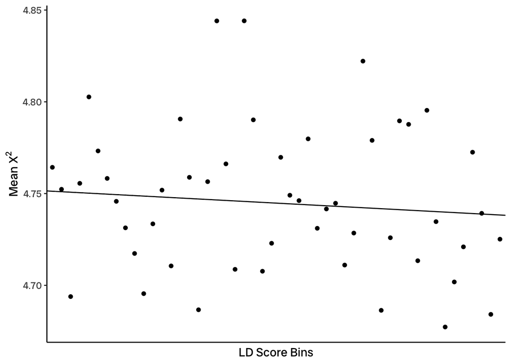

```r
# Group into bins and get summary statistics
SimBins <- Sim2 %>%
  mutate(`LD Score Bins` = cut(L2, breaks=50)) %>%
  group_by(`LD Score Bins`) %>%
  summarise(meanchi2 = mean(Z2), meanLD=mean(L2))

# Plot
ggplot(SimBins, aes(x=`LD Score Bins`, y=meanchi2))+
  geom_point() +
  theme +
  geom_abline(intercept=int, slope=jknifeEst2) +
  theme(axis.text.x = element_blank(),
        axis.ticks.x = element_blank()) +
  ylab(bquote('Mean X'^2))
```

For this dataset we can also get the equivalent p-value, to test whether the h2 value we obtained is significantly different from 0.

```r
# Get p-value
z <- h2Est/h2EstSE
print(z)
```

```
## [1] -1.022913
```

```r
p <- pnorm(z, lower.tail=FALSE)
print(p)
```

```
## [1] 0.8468256
```

Our Z-score is not very extreme, and the p-value is near 1, meaning we cannot reject the hypothesis that our h2 value is different from 0 - our data shows no SNP-heritability.